# DC 3: Plotting Data

#### Setting Labels, etc.

Let’s use the `LeisureAttend` dataset to make a polished barplot.

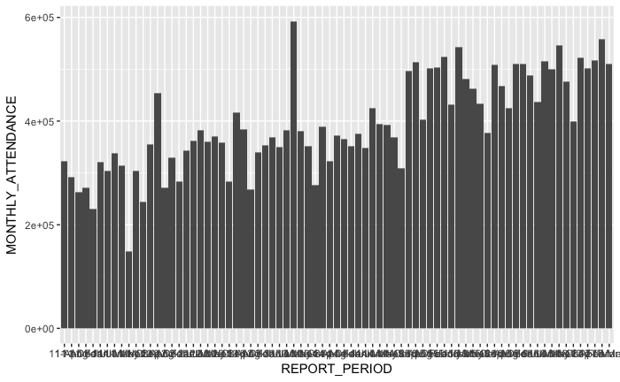

This rough plot has multiple problems. First of all, there appears to be a lot of variation by both month, and year. Maybe it is good that the dataset reflects the timeseries nature of the data, but this layout makes it hard to make comparisons directly. It should be no surprise that there is always a big drop in attendance between August and September. Maybe it would be better to group the data by months rather than the sequentially arranged variable, `REPORT_PERIOD`. We can do this like this.

[figure not shown]

Let’s re-arrange the bars for better comparison.

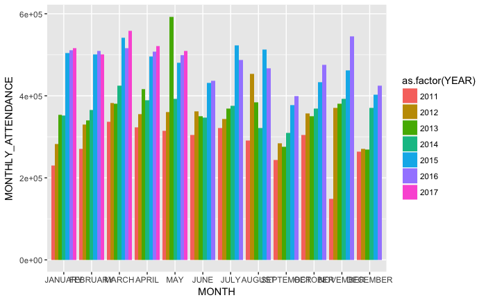

How did we change the ’LeisureAtt`dataset so that`MONTH`was arranged by time rather than alphabetically? Let's do that to`LeisureAttend`, as well.

```r
LeisureAttend$MONTH <- factor(LeisureAttend$MONTH, levels = toupper(month.name))
# Now go back and recreate 'aa' and 'bb'
```

Yes, we will finally deal with the text on the x-axis now.

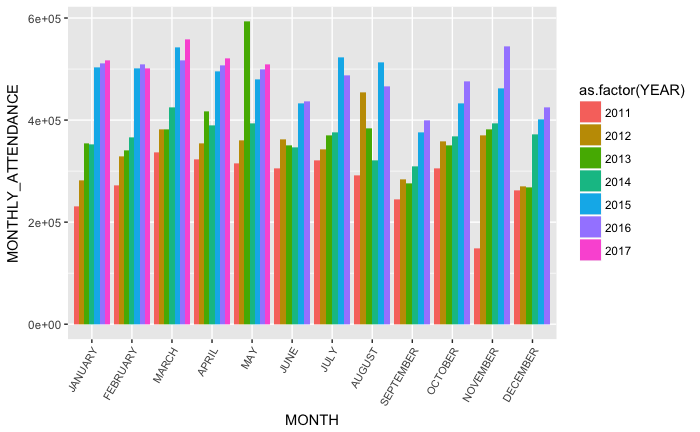

Better, but how readable is that y-axis?

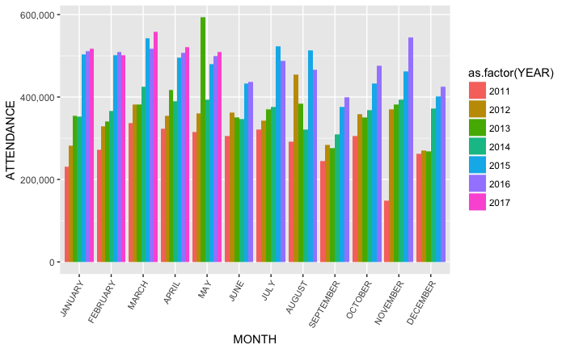

How about the legend title?

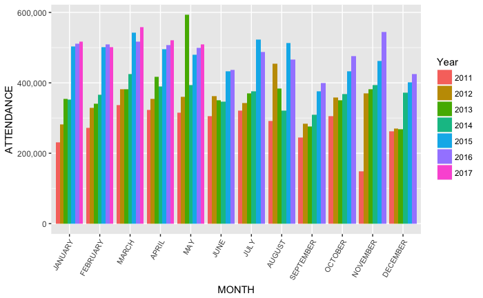

And I would be lying to say I like the colours in this plot. Let’s try something else.

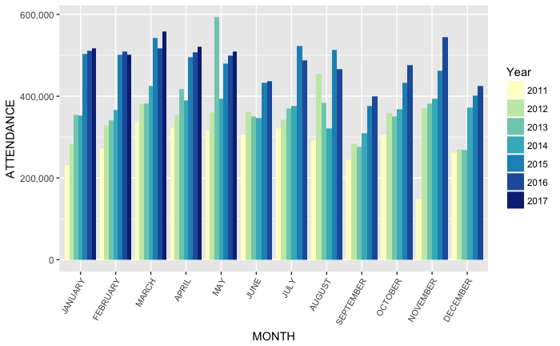

This produces the same result as below (which is how I would normally do it).

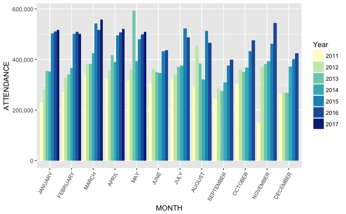

To see some other ways we could change our plot we can use the `ggthemes` package in two ways. First, we can check out some of the themes. Have a look at the vignette by running: `vignette("ggthemes")`.

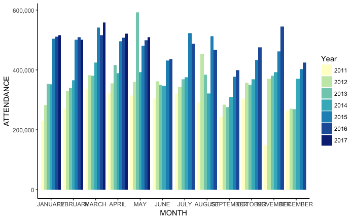

Naturally, they change the theme of the plot, but even more valuable than that is running them without the ‘()’. Running them this way, we can see some additional options that we can alter.

```r
theme_tufte
```

## Bad Barplots

Read in the dataset and take a look.

```r
dat <- read_csv("dat.csv")
datSum <- dat %>%
    group_by(Key) %>%
    summarise(mean = mean(Value), upper = mean(Value) - sd(Value), lower = mean(Value) + sd(Value))
datSum
```

Let’s make a plot from the summary data.

```r
ggplot(data = datSum, aes(x = Key, y = mean)) + geom_bar(stat = "identity") + geom_errorbar(data = datSum, aes(x = Key, ymin = upper, ymax = lower), width = 0.2, size = 1, color = "blue")
```

But, does this plot tell the truth?

```r
ggplot(dat, aes(Value, fill = Key)) + geom_density(alpha = .5)
```

```r
wilcox.test(dat$Value[dat$Key == "A"], dat$Value[dat$Key == "B"])
# t.test(dat$Value[dat$Key == "A"], dat$Value[dat$Key == "B"])
```

If you are ever tempted to make a bar plot with error bars, use a boxplot instead.

```r
ggplot(dat, aes(Key, Value)) + geom_boxplot()
```